# Introduction to Google BigQuery databases

Pablo Barbera

February 19, 2018

## Connecting to Google BigQuery

To illustrate the potential of SQL queries with large-scale databases, we’ll now work with tables hosted in BigQuery – Google’s service to enable interactive analysis of massively large datasets.

You can read more about how to setup a Google BigQuery database [here](https://cloud.google.com/bigquery/) and about their SQL syntax [here](https://cloud.google.com/bigquery/docs/reference/legacy-sql).

I have authorized this server to connect to my database and we’ll first work with one of my large datasets: all tweets posted by a random sample of 200,000 users in the US, labeled with user-level information predicted from the voter file (so two tables, one at the tweet level and another one at the user level).

```r
library(bigrquery)
project <- "usc-barbera"
set_service_token("~/credentials/bigquery-token.json")
```

The tweet-label table currently contains 388 million tweets and five variables: `id_str` (tweet ID), `user_id_str` (user ID), `datetime` (time of the tweet in BigQuery datetime format), `date` (date of tweet in string format), and `text` of the tweet

```r
## tweet-level table
query_exec(
  "SELECT COUNT(*) AS tweet_count
  FROM [usc-barbera:twitter_panel.tweets_20170721]",
    project = project)
```

```
## 0 bytes processed
```

```
##   tweet_count
## 1   388766024
```

```r
query_exec(
  "SELECT *
  FROM [usc-barbera:twitter_panel.tweets_20170721]
  LIMIT 2",
    project = project)
```

```
## 0 bytes processed
```

```
##               id_str user_id_str            datetime       date
## 1 550717339956936704   434483963 2015-01-01 18:17:00 2015-01-01
## 2 550686581515112450   400939165 2015-01-01 16:14:46 2015-01-01
##                                                                text
## 1                                                         ROLL TIDE
## 2 RT @MarcoUTLR: What have a done \U0001f633 http://t.co/qWuuB0PN1j
```

```r
get_table(project=project, dataset="twitter_panel", table="tweets_20170721")
```

```
## $kind
## [1] "bigquery#table"
##
## $etag
## [1] "\"fxz8O53ySp5NTVj5DEaTLWZ1mro/MTUxODgxMzM3MzkxNw\""
##
## $id
## [1] "usc-barbera:twitter_panel.tweets_20170721"
##
## $selfLink
## [1] "https://www.googleapis.com/bigquery/v2/projects/usc-barbera/datasets/twitter_panel/tables/tweets_20170721"
##
## $tableReference
## $tableReference$projectId
## [1] "usc-barbera"
##
## $tableReference$datasetId
## [1] "twitter_panel"
##
## $tableReference$tableId
## [1] "tweets_20170721"
##
##
## $schema
## $schema$fields
## $schema$fields[[1]]
## $schema$fields[[1]]$name
## [1] "id_str"
##
## $schema$fields[[1]]$type
## [1] "STRING"
##
## $schema$fields[[1]]$mode
## [1] "NULLABLE"
##
##
## $schema$fields[[2]]
## $schema$fields[[2]]$name
## [1] "user_id_str"
##
```

[output cut: 47 more lines]

```
##
## $numRows
## [1] "388766024"
##
## $creationTime
## [1] "1518813373917"
##
## $lastModifiedTime
## [1] "1518813373917"
##
## $type
## [1] "TABLE"
##
## $location
## [1] "US"
```

The user-level table has information about 200,000 users. For each of them, the following variables are available: `user_id_str` (user ID), `male` (TRUE if user is predicted to be male), predicted `age` (with values 1 = 18-25, 2 = 26-40, 3 = 40+), predicted `party` (with values 1 = None/Others, 2 = Democrat, 3 = Republican), predicted `race` (with values 1 = Black, 2 = Hispanic, 3 = Asian, 4 = White), predicted `turnout` in 2012, `name` of user, `description` of user, `followers_count`, `statuses_count,`friends_count`,`location`field in user's profile, and`lang` (account language).

More information about how this dataset was collected is available [in this paper](http://pablobarbera.com/static/less-is-more.pdf).

```r
# user-level table
query_exec(
  "SELECT COUNT(*) AS user_count
  FROM [usc-barbera:twitter_panel.users_subset_20160718]",
    project = project)

query_exec(
  "SELECT *
  FROM [usc-barbera:twitter_panel.users_subset_20160718]
  LIMIT 2",
    project = project)

get_table(project=project, dataset="twitter_panel", table="users_subset_20160718")
```

[output not shown]

Now let’s run a few sample queries. First, let’s count the number of tweets by year and month. See that the syntax is exactly the same we were using with SQLite database. The only difference is that now we’re using the `YEAR` and `MONTH` operators to extract the relevant components of the `datetime` field.

```r
query_exec(
  "SELECT YEAR(datetime) AS year,
    MONTH(datetime) AS month,
    COUNT(*)
  FROM [usc-barbera:twitter_panel.tweets_20170721]
  GROUP BY year, month
  ORDER BY year, month",
  project = project)
```

```
## 0 bytes processed
```

```
##    year month      f0_
## 1  2015     1  8879841
## 2  2015     2  8376297
## 3  2015     3  9379934
## 4  2015     4  9299342
## 5  2015     5  9840638
## 6  2015     6 10467819
## 7  2015     7 11483014
## 8  2015     8 12337227
## 9  2015     9 12012601
## 10 2015    10 12933774
## 11 2015    11 14258066
## 12 2015    12 15295636
## 13 2016     1 17148328
## 14 2016     2 17721276
```

[output cut: 17 more lines]

Now, let’s switch to the user-level table and look at the distribution of languages by party.

```r
query_exec(
  "SELECT lang, party, COUNT(*) AS user_count
  FROM [usc-barbera:twitter_panel.users_subset_20160718]
  GROUP BY party, lang
  ORDER BY party, user_count DESC",
  project = project)
```

```
## 0 bytes processed
```

```
##                        lang party user_count
## 1                        en     1      61521
## 2                        es     1       9783
## 3                        ja     1       1645
## 4                        id     1       1302
## 5                        pt     1        744
## 6                        fr     1        681
## 7                        ar     1        660
## 8                        tr     1        459
## 9                        ru     1        404
## 10                    en-gb     1        383
## 11                       ko     1        342
## 12                       de     1        170
## 13                       it     1        154
## 14                       NA     1        126
```

[output cut: 140 more lines]

We can also use **LIKE** to search for tweets based on their text.

```r
query_exec(
  "SELECT COUNT(*)
  FROM [usc-barbera:twitter_panel.tweets_20170721]
  WHERE lower(text) LIKE '%obama%'",
  project = project)
```

```
## 36.5 gigabytes processed
```

```
##      f0_
## 1 967995
```

```r
query_exec(
  "SELECT COUNT(*)
  FROM [usc-barbera:twitter_panel.tweets_20170721]
  WHERE lower(text) LIKE '%trump%'",
  project = project)
```

```
## 36.5 gigabytes processed
```

```
##       f0_
## 1 4067171
```

Let’s look at another example for the user-level table. As a validation of the party predictions, let’s look at mentions of key political words in users’ profiles across parties. Note that instead of `LIKE` we can directly use [regular expressions](https://cloud.google.com/bigquery/docs/reference/legacy-sql#regexp_match), which give us a bit more flexibility.

```r
query_exec(
  "SELECT party, COUNT(*) AS user_count
  FROM [usc-barbera:twitter_panel.users_subset_20160718]
  WHERE REGEXP_MATCH(LOWER(description), 'conservative|republican')
  GROUP BY party
  ORDER BY party",
  project = project)
```

```
## 0 bytes processed
```

```
##   party user_count
## 1     1         85
## 2     2         49
## 3     3        139
```

But one potential issue here: the number of users across groups may also vary, so what we need to compute is the *proportion* of users that mention these keywords on their profile. How can we do this? One option is to do it manually after collecting the data:

```r
(df <- query_exec(
  "SELECT party,
      SUM(REGEXP_MATCH(LOWER(description), 'conservative|republican')) AS user_count,
    COUNT(UNIQUE(user_id_str)) AS total_users
  FROM [usc-barbera:twitter_panel.users_subset_20160718]
  GROUP BY party
  ORDER BY party",
  project = project))
```

```
## 0 bytes processed
```

```
##   party user_count total_users
## 1     1         85       79165
## 2     2         49       73920
## 3     3        139       48652
```

```r
(df$user_count / df$total_users) * 100
```

```
## [1] 0.10737068 0.06628788 0.28570254
```

But we can also do it in one step using a `subselect`:

```r
query_exec(
  "SELECT party, user_count, total_users, 100 * (user_count / total_users) AS proportion
  FROM (SELECT party,
      SUM(REGEXP_MATCH(LOWER(description), 'conservative|republican')) AS user_count,
      COUNT(UNIQUE(user_id_str)) AS total_users
      FROM [usc-barbera:twitter_panel.users_subset_20160718]
      GROUP BY PARTY)
  ORDER BY party, proportion",
  project=project)
```

```
## 0 bytes processed
```

```
##   party user_count total_users proportion
## 1     1         85       79165 0.10737068
## 2     2         49       73920 0.06628788
## 3     3        139       48652 0.28570254
```

What is happening here? We are using a nested query, creating a new table on the spot. Let’s try to understand by at that table we created:

```r
query_exec(
  "SELECT party,
      SUM(REGEXP_MATCH(LOWER(description), 'conservative|republican')) AS user_count,
      COUNT(UNIQUE(user_id_str)) AS total_users
  FROM [usc-barbera:twitter_panel.users_subset_20160718]
  GROUP BY PARTY",
  project=project)
```

```
## 0 bytes processed
```

```
##   party user_count total_users
## 1     2         49       73920
## 2     1         85       79165
## 3     3        139       48652
```

```r
query_exec(
  "SELECT party, COUNT(*) AS user_count
  FROM [usc-barbera:twitter_panel.users_subset_20160718]
  WHERE lower(description) LIKE '%liberal%'
      OR lower(description) LIKE '%democrat%'
  GROUP BY party
  ORDER BY party",
  project = project)
```

```
## 12.0 megabytes processed
```

```
##   party user_count
## 1     1         65
## 2     2        101
## 3     3         41
```

We can also compute counts at the date level to obtain a plot showing the evolution in the number of tweets over time that e.g. mention the word `happy`.

```r
df <- query_exec(
  "SELECT date, COUNT(*) AS happy_count
  FROM [usc-barbera:twitter_panel.tweets_20170721]
  WHERE lower(text) LIKE '%happy%'
  GROUP BY date",
  project = project)
```

```
## 0 bytes processed
```

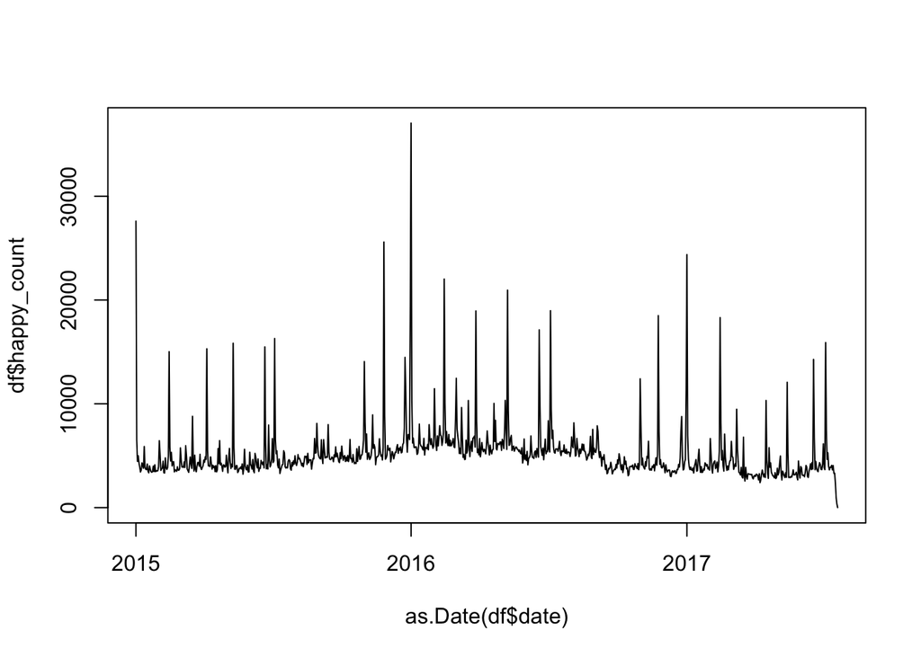

```r
df <- df[order(df$date),]
plot(as.Date(df$date), df$happy_count, type="l")
```

Which are the happiest days of the year? Two ways of doing this…

```r
head(df[order(df$happy_count, decreasing = TRUE),])
```

```
##           date happy_count
## 768 2016-01-01       37044
## 140 2015-01-01       27600
## 114 2015-11-26       25590
## 883 2017-01-01       24376
## 845 2016-02-14       22021
## 162 2016-05-08       20952
```

```r
query_exec(
  "SELECT date, COUNT(*) AS happy_count
  FROM [usc-barbera:twitter_panel.tweets_20170721]
  WHERE lower(text) LIKE '%happy%'
  GROUP BY date
  ORDER BY happy_count DESC
  LIMIT 10",
  project = project)
```

```
## 0 bytes processed
```

```
##          date happy_count
## 1  2016-01-01       37044
## 2  2015-01-01       27600
## 3  2015-11-26       25590
## 4  2017-01-01       24376
## 5  2016-02-14       22021
## 6  2016-05-08       20952
## 7  2015-12-31       19279
## 8  2016-07-04       18973
## 9  2016-03-27       18951
## 10 2016-11-24       18496
```

How did the popularity of the `#BlackLivesMatter` hashtag evolve over time?

```r
df <- query_exec(
  "SELECT date, COUNT(*) AS blm_count
  FROM [usc-barbera:twitter_panel.tweets_20170721]
  WHERE lower(text) LIKE '%blacklivesmatter%'
  GROUP BY date",
  project = project)
```

```
## 0 bytes processed
```

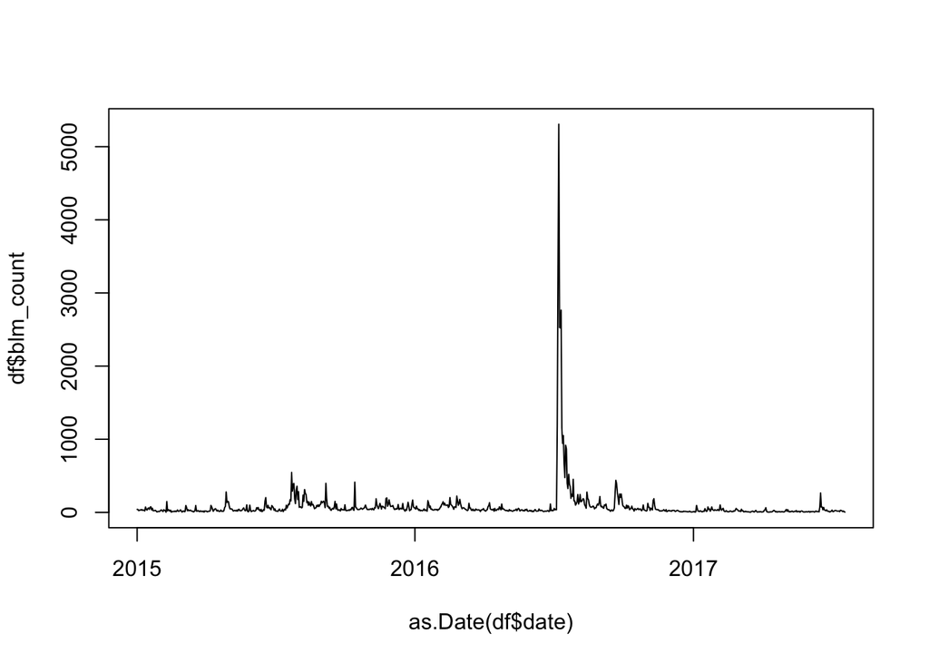

```r
df <- df[order(df$date),]
plot(as.Date(df$date), df$blm_count, type="l")
```

And in combination with JOIN, it gets really easy to merge databases to, for example, count the number of tweets mentioning a specific keyword based on user-level characteristics:

```r
query_exec(
  "SELECT users.party,
    COUNT(*) AS tweet_count
  FROM [usc-barbera:twitter_panel.users_subset_20160718] AS users
  JOIN [usc-barbera:twitter_panel.tweets_20170721] AS tweets
  ON tweets.user_id_str = users.user_id_str
  WHERE lower(text) LIKE '%immigra%'
  GROUP BY users.party,
  ORDER BY users.party",
  project = project)
```

```
## 0 bytes processed
```

```
##   users_party tweet_count
## 1           1       28273
## 2           2       34074
## 3           3       24264
```